# Ames Iowa Housing Analysis

Austin Adair

October 08, 2020

### 0.0.1 Ames Iowa Housing Analysis

In this paper I attempted to discern what factors are associated with the highest sales price of a home in Ames Iowa. The data analyzed contains housing sales prices from 2006 through 2010. Access to the database can be gained from the Ames site (http://www.cityofames.org/assessor/) by clicking on “property search” or by accessing the Beacon (http://beacon.schneidercorp.com/Default.aspx) website and inputting Iowa and Ames in the appropriate fields.

The primary purpose for this paper is to provide guidance for - Friedrich Land Development; who has been engaged in real-estate development in Ames Iowa for over 50 years. Specifically, this analysis will give insights into what housing features are associated with the highest correlation to final sales price of a house. This will allow them to better evaluate the true value of houses currently on the market and understand what features should be added to generate the highest ROI.

The reader can show any code chunk by clicking on the code button. We chose to make the default for the code hidden since we: (a) wanted to improve the readability of this document; and (b) assumed that the readers will not be interested in reading every code chunk.

### 0.0.2 Loading data

```r
rm(list = ls()) # Clears global environment
library(pacman)
p_load(DataExplorer, ggplot2, ggcorrplot, dplyr, corrplot, jtools, ggstance, broom.mixed)
data = read.csv("AmesHousing.csv", stringsAsFactors = TRUE) # reads in data set

# Correctly Code Variables
data$Bsmt.Full.Bath=factor(data$Bsmt.Full.Bath)
data$Bsmt.Half.Bath =factor(data$Bsmt.Half.Bath)
data$Full.Bath =factor(data$Full.Bath)
data$Half.Bath =factor(data$Half.Bath)
data$Bedroom.AbvGr = factor(data$Bedroom.AbvGr)
data$Kitchen.AbvGr = factor(data$Kitchen.AbvGr)
```

### 0.0.3 Data Overview

Next I will find which of our remaining variables are highly correlated to one another. In order to compare correlations in the data a function was generated using logic from Katherine Williams *How to Create a Correlation Matrix with Too Many Variables in R, 2020*. This function returns a simplified correlation plot that the correlations with a high enough significance level will have a colored circle. Highly correlated variables will be removed from the model once it is built due to the fact that they contain redundant information.

```r
# data Overview
dim(data) # gives the number of variables and observations in the data set
```

```
## [1] 2930   82
```

```r
head(data) # gives a glimpse of the head of the data
```

```
##   Order       PID MS.SubClass MS.Zoning Lot.Frontage Lot.Area Street Alley
## 1     1 526301100          20        RL          141    31770   Pave  <NA>
## 2     2 526350040          20        RH           80    11622   Pave  <NA>
## 3     3 526351010          20        RL           81    14267   Pave  <NA>
## 4     4 526353030          20        RL           93    11160   Pave  <NA>
## 5     5 527105010          60        RL           74    13830   Pave  <NA>
## 6     6 527105030          60        RL           78     9978   Pave  <NA>
##   Lot.Shape Land.Contour Utilities Lot.Config Land.Slope Neighborhood
## 1       IR1          Lvl    AllPub     Corner        Gtl        NAmes
## 2       Reg          Lvl    AllPub     Inside        Gtl        NAmes
## 3       IR1          Lvl    AllPub     Corner        Gtl        NAmes
## 4       Reg          Lvl    AllPub     Corner        Gtl        NAmes
## 5       IR1          Lvl    AllPub     Inside        Gtl      Gilbert
## 6       IR1          Lvl    AllPub     Inside        Gtl      Gilbert
##   Condition.1 Condition.2 Bldg.Type House.Style Overall.Qual Overall.Cond
```

[output cut: 83 more lines]

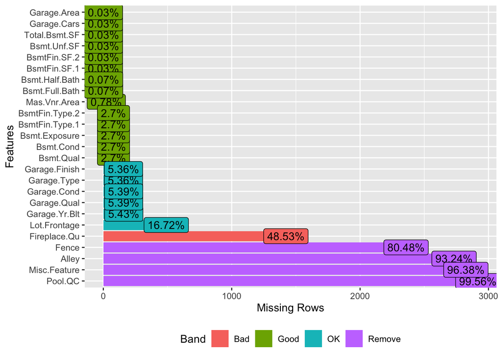

```r
# plot missing data
plot_missing(data, group = list(Good = 0.05, OK = 0.3, Bad = 0.5, Remove = 1), missing_only = TRUE, geom_label_args = list(), title = NULL, ggtheme = theme_gray(), theme_config = list(legend.position = c("bottom")))
```

```
##                Var1           Var2       Freq
## 6397          Order        Yr.Sold -0.9759929
## 2075   Exterior.1st   Exterior.2nd  0.8654165
## 4558    Gr.Liv.Area  TotRms.AbvGrd  0.8077721
## 6661   Overall.Qual      SalePrice  0.7992618
## 1315    MS.SubClass      Bldg.Type  0.7435622
## 6690    Gr.Liv.Area      SalePrice  0.7067799
## 4563  Bedroom.AbvGr  TotRms.AbvGrd  0.6722236
## 3900    X2nd.Flr.SF    Gr.Liv.Area  0.6552512
## 4457     Exter.Qual   Kitchen.Qual  0.6535235
## 6671     Exter.Qual      SalePrice -0.6476163
## 2481     Year.Built     Foundation  0.6366324
## 2315   Overall.Qual     Exter.Qual -0.6331484
## 4148    Gr.Liv.Area      Full.Bath  0.6303208
## 6687    X1st.Flr.SF      SalePrice  0.6216761
```

[output cut: 18 more lines]

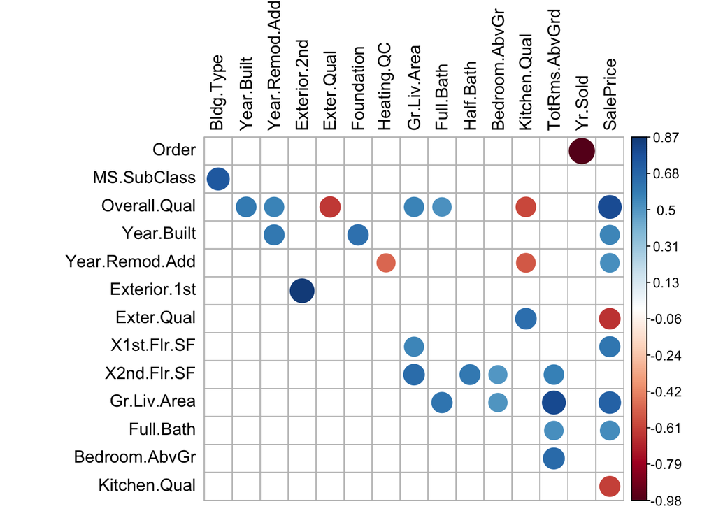

```r
# Correlation Plot

corr_simple <- function(data= data,sig=0.5){
  #convert data to numeric in order to run correlations
  #convert to factor first to keep the integrity of the data - each value will become a number rather than turn into NA
df_cor <- data %>% mutate_if(is.character, as.factor)
df_cor <- df_cor %>% mutate_if(is.factor, as.numeric)
  #run a correlation and drop the insignificant ones
corr <- cor(df_cor)
  #prepare to drop duplicates and correlations of 1
corr[lower.tri(corr,diag=TRUE)] <- NA
  #drop perfect correlations
corr[corr == 1] <- NA
  #turn into a 3-column table
corr <- as.data.frame(as.table(corr))
  #remove the NA values from above
corr <- na.omit(corr)
  #select significant values
corr <- subset(corr, abs(Freq) > sig)
  #sort by highest correlation
corr <- corr[order(-abs(corr$Freq)),]
  #print table
print(corr)
  #turn corr back into matrix in order to plot with
mtx_corr <- reshape2::acast(corr, Var1~Var2, value.var="Freq")

  #plot correlations visually
  corrplot(mtx_corr, is.corr=FALSE, tl.col="black", na.label=" ")
}
corr_simple(data) # creates a correlation plot including only highly correlated variables
```

### 0.0.4 Details on Data Preprocessing

Once we have addressed the majority of the missing values, we can then omit any variable that are still missing. In doing so we will only be eliminating 104 observation, which should have a minimal impact on developing a model.

```r
#remove any variables that had least 45% missing data

data<-select(data, -Fireplace.Qu)
data<-select(data, -Fence)
data<-select(data, -Alley)
data<-select(data, -Misc.Feature)
data<-select(data, -Pool.QC)

#impute any variables that had least 5% missing data and was not removed

# Creating Mode function

getmode <- function(data) {
  uniqv <- unique(data)
  uniqv[which.max(tabulate(match(data, uniqv)))]
}

#Garage.Finish
data$M_Garage.Finish<-as.factor(ifelse(is.na(data$Garage.Finish), 1, 0))
data$Garage.Finish[is.na(data$Garage.Finish)]<-getmode(data$Garage.Finish)
      #Garage.Type
data$M_Garage.Type<-as.factor(ifelse(is.na(data$Garage.Type), 1, 0))
data$Garage.Type[is.na(data$Garage.Type)]<-getmode(data$Garage.Type)
      #Garage.Cod
data$M_Garage.Cond<-as.factor(ifelse(is.na(data$Garage.Cond), 1, 0))
data$Garage.Cond[is.na(data$Garage.Cond)]<-getmode(data$Garage.Cond)
      #Garage.Qual
data$M_Garage.Qual<-as.factor(ifelse(is.na(data$Garage.Qual), 1, 0))
data$Garage.Qual[is.na(data$Garage.Qual)]<-getmode(data$Garage.Qual)
      #Garage.Yr.Blt
data$M_Garage.Yr.Blt<-as.factor(ifelse(is.na(data$Garage.Yr.Blt), 1, 0))
data$Garage.Yr.Blt[is.na(data$Garage.Yr.Blt)]<-median(data$Garage.Yr.Blt, na.rm = TRUE)
      #Lot.Frontage
data$M_Lot.Frontage<-as.factor(ifelse(is.na(data$Lot.Frontage), 1, 0))
data$Lot.Frontage[is.na(data$Lot.Frontage)]<-median(data$Lot.Frontage, na.rm = TRUE)
    #SalePrice
data$M_SalePrice<-as.numeric(ifelse(is.na(data$SalePrice), 1, 0))
data$SalePrice[is.na(data$SalePrice)]<-median(data$SalePrice, na.rm = TRUE)

# remove the newly created factors from the data
data<-select(data, -M_SalePrice)
data<-select(data, -M_Lot.Frontage)
data<-select(data, -M_Garage.Yr.Blt)
data<-select(data, -M_Garage.Cond)
data<-select(data, -M_Garage.Type)
data<-select(data, -M_Garage.Finish)
data<-select(data, -M_Garage.Qual)

# remove missing data so we can run a stepwise regression
data=na.omit(data)
```

### 0.0.5 Building A Linear Regression

To build an effective model we are going to create a stepwise regression. The stepwise regression will add and remove variables until an optimal model is created. The stepwise regression determined that there are a total o 173 variables that are statistically signiicant in predicting the sale price of a home in Ames Iowa.

```r
#Creating the first stepwise regression on training data

full<-lm(SalePrice~., data = data) # creating full linear regression

null<-lm(SalePrice~1, data=data) # Creating null linear regression

lm.step1<-step(null, scope=list(lower=null, upper=full), direction="both", trace=0)
```

### 0.0.6 Removing Correlate Variables

Now that we have found what variables are statistically significant, we need to remove highly correlated variables from the model. Highly correlated variables are redundant in the seance that they communicate repetitive information. We will also remove the variable neighborhoods as it contains 28 distinct levels which complicates the model and adds unnecessary degrees of freedom. Likewise, removing the correlated variables and neighborhoods in our model has a minimal impact in the adjusted R squared values while creating a simpler model.

Our simpler model contains a ar ewer 103 variables while maintaining a relatively high R squared value. The new model has an adjusted R squared value of 0.84 in comparison to the previous model which had an adjusted R square value of 0.91.

This means that in our simpler model 84% of the variance in the final sales price of a house in Ames Iowa is explained by our model.

```r
lm = lm(SalePrice ~ Overall.Qual + BsmtFin.SF.1 + Roof.Matl + MS.SubClass + Bsmt.Exposure + Condition.2 + Sale.Condition + Garage.Area + Overall.Cond + Bsmt.Qual + Total.Bsmt.SF + Lot.Area + Pool.Area + Screen.Porch + Functional + Exterior.1st + Land.Contour + Bsmt.Full.Bath + Mas.Vnr.Area + Condition.1 + Fireplaces + Garage.Yr.Blt + Mas.Vnr.Type + BsmtFin.SF.2 + Wood.Deck.SF + Garage.Finish + BsmtFin.Type.1 + MS.Zoning + Land.Slope + Garage.Cars + Kitchen.AbvGr + Low.Qual.Fin.SF + Utilities, data = data)
```

### 0.0.7 Create A Graph Showing The Coefficient Values

```r
lm2 = abs(lm$coefficients)
sort(lm2, decreasing = TRUE)
```

```
##           (Intercept)      Roof.MatlWdShngl        Roof.MatlMetal
##          8.835598e+05          6.288136e+05          5.999583e+05
##      Roof.MatlMembran      Roof.MatlTar&Grv      Roof.MatlCompShg
##          5.970932e+05          5.583511e+05          5.576701e+05
##      Roof.MatlWdShake         Roof.MatlRoll       Condition.2PosN
##          5.545526e+05          5.435064e+05          8.880444e+04
##       UtilitiesNoSewr   Exterior.1stPreCast       UtilitiesNoSeWa
##          8.448933e+04          7.535950e+04          6.395710e+04
##       Bsmt.Full.Bath3       Condition.2PosA           Bsmt.QualTA
##          5.903897e+04          5.883101e+04          4.646097e+04
##   Exterior.1stAsphShn           Bsmt.QualFa           Bsmt.QualGd
##          4.432380e+04          4.158917e+04          4.021091e+04
##        Kitchen.AbvGr3     Exterior.1stStone         Land.SlopeSev
##          3.913022e+04          3.587006e+04          3.354262e+04
##       Condition.2RRAn    Mas.Vnr.TypeCBlock      Mas.Vnr.TypeNone
##          2.626115e+04          2.320079e+04          2.278563e+04
##        Kitchen.AbvGr2       Condition.1PosN       Condition.1PosA
##          2.211630e+04          2.068990e+04          2.062262e+04
##          Overall.Qual   Exterior.1stPlywood        Kitchen.AbvGr1
##          1.954525e+04          1.889631e+04          1.867170e+04
## Sale.ConditionPartial        FunctionalMaj2      Garage.FinishRFn
##          1.826365e+04          1.749428e+04          1.645315e+04
##      Garage.FinishUnf       Land.ContourHLS       Condition.2RRAe
##          1.582203e+04          1.579729e+04          1.552463e+04
##           Bsmt.QualPo Sale.ConditionAdjLand       Condition.2RRNn
##          1.507344e+04          1.502905e+04          1.340200e+04
##   Exterior.1stWdShing         FunctionalSev       Condition.1Norm
##          1.332365e+04          1.317879e+04          1.228420e+04
##            Fireplaces   Exterior.1stHdBoard     Mas.Vnr.TypeStone
##          1.206003e+04          1.180499e+04          1.145820e+04
##   Mas.Vnr.TypeBrkFace         Land.SlopeMod      Garage.FinishFin
##          1.107927e+04          1.061534e+04          1.008198e+04
##   Exterior.1stImStucc    Exterior.1stCBlock   Exterior.1stBrkFace
##          9.584840e+03          9.438719e+03          8.936658e+03
##       Condition.2Norm      Condition.2Feedr   Exterior.1stWd Sdng
##          8.558863e+03          8.556402e+03          8.265702e+03
##           MS.ZoningFV         FunctionalSal       Land.ContourLow
##          7.670076e+03          7.577346e+03          7.496497e+03
##     BsmtFin.Type.1GLQ       Land.ContourLvl           Garage.Cars
##          6.967011e+03          6.913822e+03          6.889349e+03
```

[output cut: 15 more lines]

```
##          2.625533e+03          2.260085e+03          1.819602e+03
##        FunctionalMin2     BsmtFin.Type.1BLQ       Condition.1RRAe
##          1.610715e+03          1.251453e+03          9.911265e+02
##  Sale.ConditionFamily   Exterior.1stVinylSd     BsmtFin.Type.1Rec
##          9.779985e+02          9.457709e+02          9.106891e+02
##       Bsmt.Full.Bath1         Garage.Yr.Blt             Pool.Area
##          1.523105e+02          1.414235e+02          1.190452e+02
##       Bsmt.ExposureGd          Mas.Vnr.Area          Screen.Porch
##          1.084436e+02          6.840948e+01          5.482265e+01
##           Garage.Area           MS.SubClass       Low.Qual.Fin.SF
##          2.796098e+01          2.635996e+01          2.474350e+01
##         Total.Bsmt.SF          Wood.Deck.SF          BsmtFin.SF.1
##          2.259629e+01          2.003833e+01          1.581485e+01
##          BsmtFin.SF.2              Lot.Area
##          1.049948e+01          1.074968e+00
```

[figure not shown]

```r
lm2 = (head(sort(lm2, decreasing = TRUE), 6))
barplot(lm2,
        main = "Top 6 Coefficients (ABS)",
        names.arg = c("Shngl", "Roll", "Shake", "CompShg", "Membran", "Metal"))
```

### 0.0.8 Create A Graph Sjowing The Prediction Ability Of The Model

The histogram of the residuals of a model is a useful proxy for the predictive power of a model. Overall, our model’s residuals are normally distributed and centered around 0. This, alongside our large R squared value, means that our linear regression model is an appropriate predictor for the final sales price of a home in Ames Iowa.

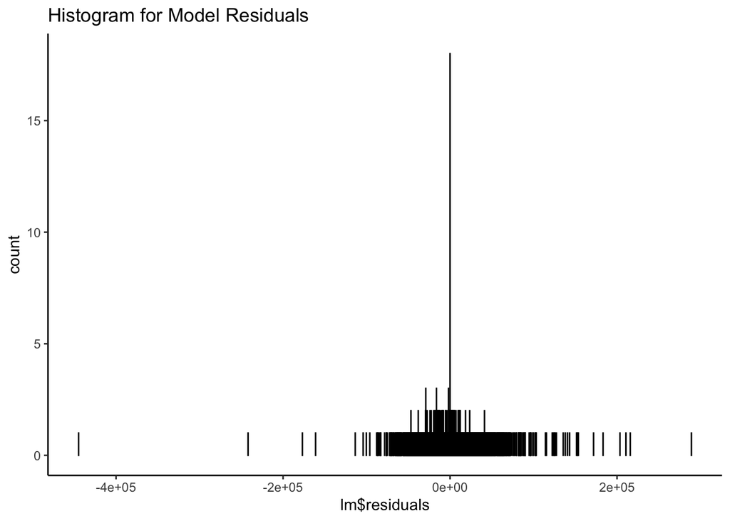

```r
ggplot(data=data, aes(lm$residuals)) +
  geom_histogram(binwidth = 1, color = "black", fill = "purple4") +
  theme(panel.background = element_rect(fill = "white"),
        axis.line.x=element_line(),
        axis.line.y=element_line()) +
  ggtitle("Histogram for Model Residuals")
```

### 0.0.9 Conclusion

In conclusion, our model was successful in answering the original question of what factors are associated with the highest sales price of a home in Ames Iowa. Although our final model contained a plethora (103) of statistically significant variables there were some that had exceptionally high correlations.

In analyzing our model we can conclude that the most important factor in predicting the final sale price of a house would be the roofing materiel used. In a business sense, we will need to do additional exploratory research to understand why roofing material is such an important actor in predicting tyhe inal sale price. This information can help guide Friedrich Land Development to determine what roofing material they can utilize for the best ROI.

Furthermore, our linear regression is able to give insights into several other features of a house and is able to quantify the value (in dollars) of said feature. This can be a good tool in both evaluating the current price of a home on the market, but also in determining what renovations to add next.

Moving forward, there are some additional questions that are still unanswered:

- Is this model useful at explaining the predicted sales price of homes outside of Iowa?
- Is this model still relevant in 2020?
- Have consumers preference in housing features shifted significantly from when the data was collected (2006-2010) until today?